# HPAI spillover — manuscript exhibits

## Table 1. Minnesota sample and conditions, by season

Table 1. Minnesota spillover sample and conditions, by meteorological season

| Variable | Winter | Spring | Summer | Fall | Year-round |
| --- | --- | --- | --- | --- | --- |
| Spillover events | 3 | 60 | 1 | 21 | 85 |
| Case cells | 3 | 52 | 1 | 21 | 73 |
| Referent cell-days | 69 | 1,388 | 29 | 482 | 1,968 |
| Referents per case | 23 | 23 | 29 | 23 | 23 |
| Temperature (°C), median (IQR) | -9.8 (-16.7, -3.7) | 4.0 (-0.1, 11.6) | 22.0 (20.1, 23.9) | 11.3 (2.8, 17.3) | 8.5 (-2.5, 19.3) |
| 90-day shock (°C), median (IQR) | -10.4 (-13.7, -6.9) | 9.9 (7.5, 11.6) | 7.5 (1.3, 9.9) | -9.0 (-12.7, -5.6) | -2.8 (-10.6, 8.0) |
| vs 25-yr normal, median (95% CrI) | **-2.4 (-3.7, -1.1)** | -1.3 (-3.8, 1.3) | 0.8 (-0.1, 1.7) | **1.3 (0.7, 1.9)** | -0.2 (-0.6, 0.3) |
| Precipitation (mm), median (IQR) | 0.2 (0.0, 1.2) | 0.3 (0.0, 3.2) | 0.1 (0.0, 2.0) | 0.0 (0.0, 0.8) | 0.1 (0.0, 1.5) |
| 90-day shock (% vs 90-day baseline), median (IQR) | -3 (-18, 20) | 18 (-9, 54) | -10 (-28, 14) | -18 (-34, 6) | -6 (-24, 23) |
| vs 25-yr normal, median (95% CrI) | 0.3 (-0.2, 0.8) | 0.5 (-0.7, 1.7) | -0.9 (-1.8, -0.0) | -0.2 (-0.9, 0.5) | -0.1 (-0.5, 0.3) |
| Soil moisture (% vol), median (IQR) | 34.6 (32.3, 36.3) | 37.7 (34.8, 39.8) | 26.8 (21.2, 32.0) | 30.9 (24.6, 35.4) | 33.0 (26.0, 36.4) |
| 90-day shock (% vol), median (IQR) | 0.7 (-0.8, 2.6) | 0.7 (-0.9, 2.5) | -5.2 (-7.9, -1.6) | 0.8 (-1.6, 3.3) | 0.0 (-2.1, 2.3) |
| vs 25-yr normal, median (95% CrI) | 0.5 (-1.2, 2.2) | **1.8 (0.1, 3.7)** | -2.4 (-5.0, 0.2) | -0.5 (-4.2, 3.4) | -0.5 (-2.0, 1.0) |
| Wind speed (m/s), median (IQR) | 2.7 (1.8, 3.9) | 3.3 (2.3, 4.8) | 2.8 (2.0, 3.6) | 2.9 (2.1, 4.1) | 2.9 (2.0, 4.0) |
| 90-day shock (m/s), median (IQR) | 0.0 (-0.4, 0.4) | 0.3 (-0.3, 0.9) | -0.4 (-0.8, 0.0) | 0.2 (-0.1, 0.6) | 0.0 (-0.4, 0.5) |
| vs 25-yr normal, median (95% CrI) | 0.1 (-0.2, 0.4) | **0.4 (0.1, 0.7)** | 0.3 (-0.1, 0.6) | 0.1 (-0.1, 0.2) | 0.2 (0.0, 0.3) |
| Runoff (mm), median (IQR) | 0.00 (0.00, 0.00) | 0.01 (0.00, 0.08) | 0.00 (0.00, 0.01) | 0.00 (0.00, 0.00) | 0.00 (0.00, 0.01) |
| 90-day shock (% vs 90-day baseline), median (IQR) | -2 (-3, -1) | 1 (-2, 12) | -8 (-12, -3) | -2 (-5, -1) | -2 (-6, -0) |
| vs 25-yr normal, median (95% CrI) | 0.01 (-0.04, 0.06) | 0.11 (-0.14, 0.35) | -0.18 (-0.36, -0.00) | **-0.05 (-0.10, -0.01)** | -0.04 (-0.11, 0.03) |
| Anseriformes, median (IQR) | 0.0 (0.0, 0.0) | 15.0 (8.0, 33.6) | 2.7 (0.0, 7.8) | 0.0 (0.0, 11.8) | 1.6 (0.0, 11.3) |
| Predators, median (IQR) | 0.5 (0.4, 0.6) | 0.7 (0.5, 0.9) | 0.3 (0.2, 0.6) | 0.5 (0.3, 0.6) | 0.5 (0.3, 0.6) |

Case-crossover sample: 85 spillover events in 73 cells; a stratum takes the season of its case day. Conditions are summarised over all cell-days in those 73 cells. The 90-day shock is the mean of the last 7 days minus the mean of the preceding 90; for precipitation and runoff it is a log ratio, shown as percent change. Deviations are from the 1997-2021 weekly normal for that cell, reported as the median across cells with a 95% credible interval from an INLA AR(1) model over day. CrI = credible interval; IQR = interquartile range.

- Sample block first — events, case cells, referent cell-days and referents per case, by the season of the case day — then, for each of the five meteorological exposures: the level, the **90-day shock** in natural units, and the deviation from the 25-year normal.
- Spring carries 60 of the 85 events. Spring temperature (median 4.0 °C) is not unusual against the 25-year normal (−1.3 (−3.8, 1.3)); spring soil moisture is wetter than normal (1.8 (0.1, 3.7) %vol).
- Anseriformes median 15.0 in spring versus 0.0 in winter and fall — the exposure contrast the paper rests on.
- Deviations are medians across cells with a credible interval from an AR(1) over days.

# Supplement

## Figure S1. Case and referent selection

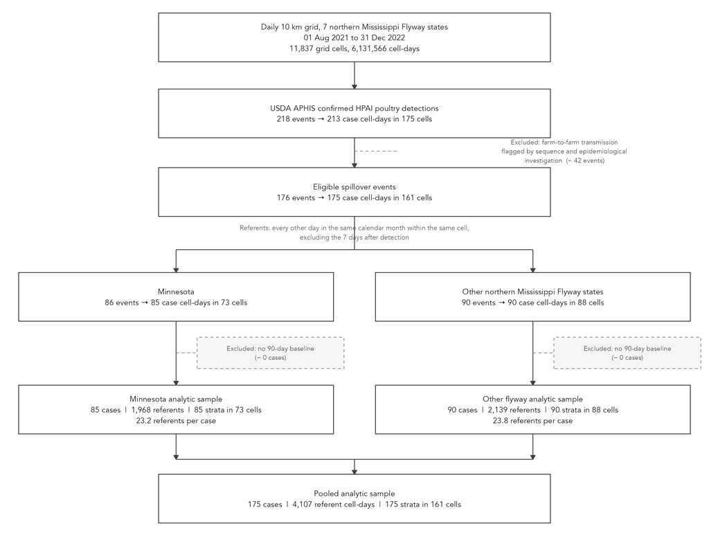

- 176 eligible events → 175 case cell-days in 161 cells. The 2021 ERA5 warm-up removed the 90-day-baseline exclusion that previously cost eight cases.